# Brief Exploration of ELS:2002 Questionnaries as Rasch Items to Compare Security Measures in U.S. High Schools

Adapted From: Misbehavior, Suspensions and Security Measures in High School: Racial/Ethnic and Gender Differences (Finn & Servoss, 2014)

Joshua Sinamo

## Appendix Overview

- Preface & List of Security Questions
- External Requirements
- General Data Cleaning for All Analysis
- Finn and Servoss Question Set - Initialization
- My Alternative Rasch Model - Initialization
- Hyperparameter Tuning - Computation
- Hyperparameter Tuning - Visualization (AIC, BIC, RMSE, Mean of RanEf coeff)
- Hyperparameter Tuning - Visualization (Fixed Effect Coefficients)
- Assessment of Indexing Methods between The Two Models
- Model Comparison via Bootstrapping - Initialization
- Model Comparison via Bootstrapping - Data Cleaning
- Model Comparison via Bootstrapping - Data Cleaning
- Expected Coverage Length Comparison
- Future Analysis

## Preface & List of Security Questions

This is a mini assessment comparing two IRT (or Rasch) models involving two different sets of questions. These models are purposed for calculation, comparison and indexing of security measures across U.S. high schools. The only difference between the two models are the set of questions that are used to measure security level. Finn & Servoss (2014) in their paper: Misbehavior, Suspensions and Security Measures in High School: Racial/Ethnic and Gender Differences, proposed a set of 7 questions to measure security level. As an independent analyst with no domain knowledge in school security measurements, their set of questions seems to be qualitatively redundant and therefore I experimented with an alternative set by selecting questions that seemingly unrelated with each other. Finn & Servoss used the Education Longitudinal Study (NCES, 2002) survey data, which is available via NCES website. In ELS:2002 survey, school administrators were asked about their schools’ demographics, academic performance, and among other things security measures in their institution.

The 24 security questions from ELS:200 Admin Questionnaire are as follows:

38. During this school year (2001-2002), is it a practice of your school to do the following? (If your school changed its practices in the middle of the school year, please answer regarding your most recent practice.) (MARK ONE RESPONSE ON EACH LINE) (Yes; No)
1. Control access to buildings during school hours
2. Control access to grounds during school hours
3. Require students pass through metal detector
4. Random metal detector checks on students
5. Close campus for students during lunch
6. Random dog sniffs to check for drugs
7. Random sweeps for contraband
8. Require drug testing for any students
9. Require students to wear uniforms
10. Enforce strict dress code
11. Require clear book bags/ban book bags
12. Require students to wear badges/picture ID
13. Require faculty/staff to wear badges/picture ID
14. Use security cameras to monitor school
15. Telephones in most classrooms
16. Emergency call button in classrooms
39. Which of the following does your school do to involve or help parents deal with school discipline issues? (MARK ONE RESPONSE ON EACH LINE) (Yes; No)
1. Process to get parent input on discipline policies
2. Training parents to deal with problem behavior
3. Program involves parents in school discipline
40. During the 2001-2002 school year, did your school regularly use paid law enforcement or security services at school at the following times? (MARK ONE RESPONSE ON EACH LINE) (Yes; No)
1. Use paid security at any time during school hours
2. Use paid security as students arrive or leave
3. Use paid security at school activities
4. Use paid security outside of school hours/activities
5. Use paid security at other time

## Methods Sources

- On Security Questions and Literature

  Finn, Jeremy D. & Servoss, Timothy J. (2014). Misbehavior, Suspensions, and Security Measures in High Schools: Racial/Ethnic and Gender Differences. Journal of Applied Research on Children Volume 5 Issue 2 https://digitalcommons.library.tmc.edu/cgi/viewcontent.cgi?article=1211&context=childrenatrisk
- On Item Response Theory using LMER package in R

  de Boeck, P., Bakker, M., Zwitser, R., Nivard, M., Hofman, A., Tuerlinckx, F., & Partchev, I. (2011). The estimation of item response models with the lmer function from the lme4 package in R. Journal of Statistical Software, 39(12), 1-28.
- On Bias-Corrected & Acceleraated Confidence Interval - Source

  Efron, B.; Tibshirani, R. Bootstrap Methods for Standard Errors, Confidence Intervals, and Other Measures of Statistical Accuracy. Statist. Sci. 1 (1986), no. 1, 54-75. doi:10.1214/ss/1177013815. https://projecteuclid.org/euclid.ss/1177013815
- On Bias-Corrected & Accelerated Confidence Interval - R Implementation

  Kropko, J., & Harden, J. (2020). Beyond the Hazard Ratio: Generating Expected Durations from the Cox Proportional Hazards Model. British Journal of Political Science, 50(1), 303-320.  
  doi:10.1017/S000712341700045X. https://cran.r-project.org/web/packages/coxed/coxed.pdf

## External Requirements

- What : Loading required libraries & dataset

```r
# to clean up global environment, run this
rm(list = ls())
```

```r
library(lme4)         ; library(tidyr)
library(dplyr)        ; library(ggplot2)
library(reshape2)     ; library(Kendall)
library(parallel)     ; library(gplots)
library(graphics)     ; library(dendextend)
library(grid)         ; library(directlabels)
library(RColorBrewer) ; library(coxed)
library(gridExtra)
```

```r
dat <- read.csv("./Downloads/project/els_02_12_byf3pststu_v1_0.csv")
```

## General Data Cleaning for All Analysis

- What : Data cleaning in accordance to NCES ELS 2002 codebook

```r
dataSecurity <- dat %>% dplyr::select("F1SCH_ID", "BYA38A", "BYA38B", "BYA38C", "BYA38D", "BYA38E",
                                      "BYA38F", "BYA38G", "BYA38H", "BYA38I", "BYA38J", "BYA38K",
                                      "BYA38L", "BYA38M", "BYA38N", "BYA38O", "BYA38P", "BYA39A",
                                      "BYA39B", "BYA39C", "BYA40A", "BYA40B", "BYA40C", "BYA40D",
                                      "BYA40E")
dataSecurity <- unique(dataSecurity[dataSecurity$F1SCH_ID > 1000 &
                                    dataSecurity$BYA38A != -8 &
                                    dataSecurity$BYA38A != -7 &
                                    dataSecurity$BYA38A != -4, ])
names(dataSecurity)[2:25] <- substring(colnames(dataSecurity[,c(2:25)]), first = 4)
names(dataSecurity)[1] <- "school"
rownames(dataSecurity) <- NULL
dataSecurity[dataSecurity == -9] <- NA
head(data.frame(dataSecurity))
```

```
##   school X38A X38B X38C X38D X38E X38F X38G X38H X38I X38J X38K X38L X38M X38N
## 1   1011    1    1    0    0    0    0    0    1    0    0    0    0    0    0
## 2   1021    1    1    1    1    1    0    1    0    1    1    0    1    1    1
## 3   1022    1    0    0    0    0    0    0    0    0    0    0    0    1    0
## 4   1031    1    1    0    0    1    0    1    1    0    1    0    1    1    1
## 5   1033    1    1    0    0    1    0    0    0    0    0    0    0    0    1
## 6   1041    1    0    0    0    0    0    1    0    0    1    0    0    1    1
##   X38O X38P X39A X39B X39C X40A X40B X40C X40D X40E
## 1    1    1    1    0    0    1    1    0    0    0
## 2    1    0    1    1    1    1    1    1    0    1
## 3    1    0    0    0    0    0    0    1    0    0
## 4    1    1    1    1    1    1    1    1    1    1
## 5    1    0    1    0    0    1    1    1    1    0
## 6    1    0    1    1    0    1    1    1    0    0
```

## Finn and Servoss Question Set - Initialization

- What : Imitating Finn & Servoss’ set of questions & transform the data into item-response set
- Why : Assess & compare the two models later (1)
- How : Literature analysis from Finn & Servoss (2014)

List of Finn & Servoss’ Selected Questions:

38. During this school year (2001-2002), is it a practice of your school to do the following? (If your school changed its practices in the middle of the school year, please answer regarding your most recent practice.) (MARK ONE RESPONSE ON EACH LINE) (Yes; No)
3. Require students pass through metal detector
4. Random metal detector checks on students
5. Random dog sniffs to check for drugs
6. Random sweeps for contraband
7. Require drug testing for any students
8. Use security cameras to monitor school
40. During the 2001-2002 school year, did your school regularly use paid law enforcement or security services at school at the following times? (MARK ONE RESPONSE ON EACH LINE) (Yes; No)
1. Use paid security at any time during school hours

Previously, I determined that this set is qualitatively redundant because, for example, 38C and 38D seemingly covers the same things, also 38F and 3H in the same manner.

```r
# FINN AND SERVOS SET OF QUESTIONS

FandS_set <- dataSecurity %>% select("school", "38C", "38D", "38H", "38G", "38N", "40A", "38F")
FandS_rasch <- FandS_set %>% tidyr::gather("item", "response", -school)
```

## My Alternative Rasch Model - Initialization

- What : Providing my set of security questions & transform the data into item-response set
- Why : Assess & compare the two models later (2)
- How : Finding 7 questions in ELS:2002 in which qualitatively less overlapping with each other

In my perspective, these seven questions will result in less overlaps between questions

My alternative set of questions:

38. During this school year (2001-2002), is it a practice of your school to do the following? (If your school changed its practices in the middle of the school year, please answer regarding your most recent practice.) (MARK ONE RESPONSE ON EACH LINE) (Yes; No)
3. Require students pass through metal detector
4. Close campus for students during lunch
5. Require drug testing for any students
6. Enforce strict dress code
7. Require clear book bags/ban book bags
39. Which of the following does your school do to involve or help parents deal with school discipline issues? (MARK ONE RESPONSE ON EACH LINE) (Yes; No)
3. Program involves parents in school discipline
40. During the 2001-2002 school year, did your school regularly use paid law enforcement or security services at school at the following times? (MARK ONE RESPONSE ON EACH LINE) (Yes; No)
5. Use paid security at other time

```r
# MY ALTERNATIVE SET OF QUESTIONS
alt_set <- dataSecurity %>% select("school", "38H", "38K", "38C", "38E", "40E", "39C", "38J")
alt_rasch <- alt_set %>% tidyr::gather("item", "response", -school)
```

## Hyperparameter Tuning - Computation

- What : Selecting the minimal nAGQ where the metrics start to stabilize; although the difference is minimal, I’m looking for precision. Also, catching failure to converge
- Why : Need appropriate nAGQ to have a more precise & unbiased model comparison (more nAGQ = longer computation)
- How : Comparison of RMSE, fixed effect coefficients & means of random effect coefficients w.r.t nAGQ

```r
n = 20
RMSE_ori       <- rep(NA, n) ; RMSE_alt       <- rep(NA, n)
RANEF_mean_ori <- rep(NA, n) ; RANEF_mean_alt <- rep(NA, n)
FIXEF_ori      <- rep(NA, n) ; FIXEF_alt      <- rep(NA, n)
AIC_ori        <- rep(NA, n) ; AIC_alt        <- rep(NA, n)
BIC_ori        <- rep(NA, n) ; BIC_alt        <- rep(NA, n)

for (i in 1:n){

  tryCatch({rasch_lmer_ori_NAGQ <- glmer(response ~ 0 + item + (1|school),
                                         family = binomial, data = FandS_rasch, nAGQ = i-1)},
           warning = function(warn2) {cat("Finn & Servoss at nAGQ = ", i-1, "\n")
                                      warning(warn2)})

  tryCatch({rasch_lmer_alt_NAGQ <- glmer(response ~ 0 + item + (1|school),
                                         family = binomial, data = alt_rasch, nAGQ = i-1)},
           warning = function(warn2) {cat("Alternative at nAGQ    = ", i-1, "\n")
                                      warning(warn2)})

  RMSE_ori[i]  <- sqrt(mean(resid(rasch_lmer_ori_NAGQ)^2))
  RMSE_alt[i]  <- sqrt(mean(resid(rasch_lmer_alt_NAGQ)^2))
  FIXEF_ori[i] <- list(fixef(rasch_lmer_ori_NAGQ))
  FIXEF_alt[i] <- list(fixef(rasch_lmer_alt_NAGQ))
  RANEF_mean_ori[i] <- mean(ranef(rasch_lmer_ori_NAGQ)$school[["(Intercept)"]])
  RANEF_mean_alt[i] <- mean(ranef(rasch_lmer_alt_NAGQ)$school[["(Intercept)"]])
  AIC_ori[i]        <- AIC(rasch_lmer_ori_NAGQ) ; AIC_alt[i]        <- AIC(rasch_lmer_alt_NAGQ)
  BIC_ori[i]        <- BIC(rasch_lmer_ori_NAGQ) ; BIC_alt[i]        <- BIC(rasch_lmer_alt_NAGQ)

}
```

```
## Finn & Servoss at nAGQ =  6
```

```
## Finn & Servoss at nAGQ =  9
```

## Hyperparameter Tuning - Visualization (RMSE, Mean of RanEf Intercept Coeffs.)

- What : Visualizing the results from nAGQ optimization above
- Why : To see what is the minimum value of nAGQ that can be considered as stable (1)
- How : Find the minimal value where there’s no considerable fluctuation of the aforementioned measurements. GLMER ignores REML and uses ML, therefore it is legitimate to use AIC and BIC to compare models with different fixed effects

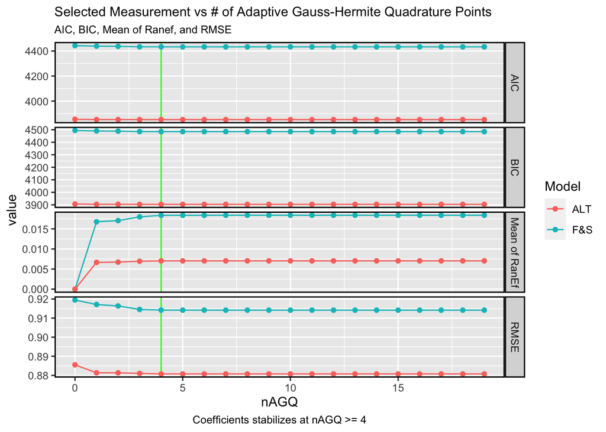

```r
assessment_data <- data.frame("measurement" = rep(c("AIC", "BIC", "RMSE", "Mean of RanEf"),
                                                  each = 40),
                              "model" = rep(c("F&S", "ALT"), each = 20, times = 4),
                              "value" = c(c(AIC_ori), c(AIC_alt), c(BIC_ori), c(BIC_alt),
                                          c(RMSE_ori), c(RMSE_alt),
                                          c(RANEF_mean_ori), c(RANEF_mean_alt)),
                              "nAGQ" = rep(seq(from = 0, to = 19), times = 8))

ggplot(data = assessment_data, aes(x = nAGQ, y = value, color = model)) +
  geom_vline(xintercept = 4, color = "green") +
  facet_grid(measurement~., scales = "free") + geom_line() + geom_point() +
  labs(color    = "Model", caption = "Coefficients stabilizes at nAGQ >= 4",
       title    = "Selected Measurement vs # of Adaptive Gauss-Hermite Quadrature Points",
       subtitle =  "AIC, BIC, Mean of Ranef, and RMSE") +
  theme(panel.spacing     = unit(0.20, "lines"),
        panel.border     = element_rect(color = "black", fill = NA, size = 1),
        strip.background = element_rect(color = "black", size = 1),
        plot.caption     = element_text(hjust = 0.5, size = 9),
        plot.title       = element_text(size = 11),
        plot.subtitle    = element_text(size = 9))
```

- Result :
  - Number of Minimal Gauss-Hermit Quadrature needed >= 4
  - My model has better AIC, BIC, RMSE, and mean of random intercepts are closer to 0 (although negligible)

## Hyperparameter Tuning - Visualization (Fixed Effect Coefficients)

- What : Visualizing the fixed effect coefficients from nAGQ optimization above
- Why : To check what is the minimum value of nAGQ that can be considered as stable (2)
- How : Finding the minimal value where there’s no considerable fluctuation of the fixed effects coefficients

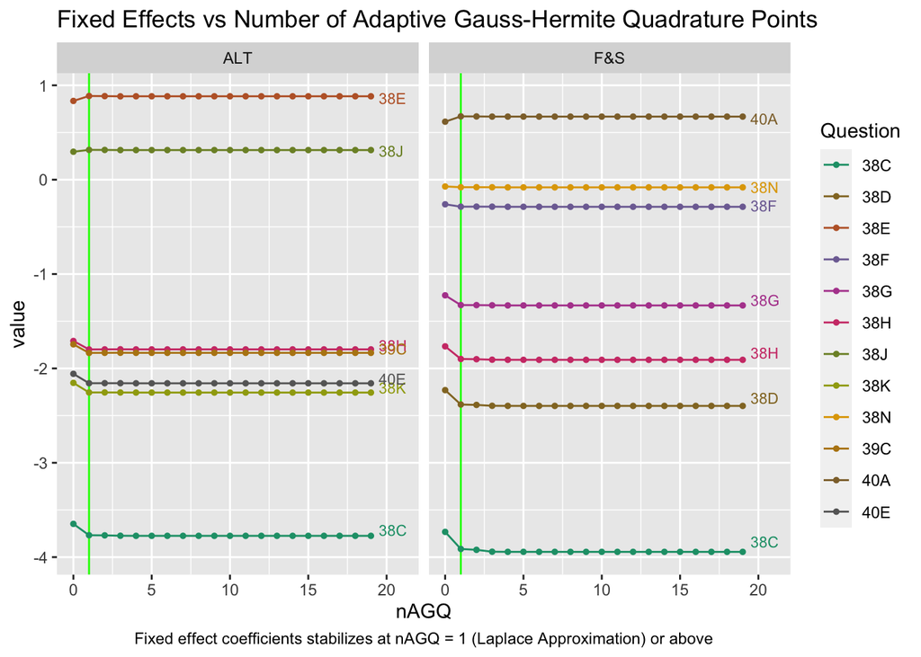

```r
FIXEF_comb_ori<- FIXEF_ori[[1]]
FIXEF_comb_alt<- FIXEF_alt[[1]]
for(i in 2:20){
  FIXEF_comb_ori <- rbind(FIXEF_comb_ori, FIXEF_ori[[i]])
  FIXEF_comb_alt <- rbind(FIXEF_comb_alt, FIXEF_alt[[i]])
}

fixef_coef_ori0 <- data.frame(FIXEF_comb_ori);
fixef_coef_ori0$nAGQ <- seq(0,19); fixef_coef_ori0$model <- "F&S"
fixef_coef_ori <- melt(fixef_coef_ori0, id.vars = c("nAGQ", "model"))
fixef_coef_alt0 <- data.frame(FIXEF_comb_alt);
fixef_coef_alt0$nAGQ <- seq(0,19); fixef_coef_alt0$model <- "ALT"
fixef_coef_alt <- melt(fixef_coef_alt0, id.vars = c("nAGQ", "model"))

fixef_graph_data <- rbind(fixef_coef_ori, fixef_coef_alt)
fixef_graph_data$variable <- substring(fixef_graph_data$variable, first = 5)

ggplot(data = fixef_graph_data, aes(x = nAGQ, y = value, colour = variable)) +
  xlim(0,21) + geom_vline(xintercept = 1, color = "green") +
  facet_grid(~model, scales = "free") + geom_line() + geom_point(size = 1) +
  labs(color   = "Question",
       title   = "Fixed Effects vs Number of Adaptive Gauss-Hermite Quadrature Points ",
       caption = "Fixed effect coefficients stabilizes at nAGQ = 1 (Laplace Approximation) or above") +
  theme(plot.caption = element_text(hjust = 0.5)) +
  geom_dl(aes(label = variable, x = 19.5), method = list(dl.combine("last.points"), cex = 0.7)) +
  scale_color_manual(values = colorRampPalette(brewer.pal(name = "Dark2", n = 8))(12))
```

- Result :
  - Number of Minimal Gauss-Hermit Quadrature needed >= 1 from the prior results, I decided to proceed with nAGQ = 4
  - It seems that fixed effect coefficients of Finn & Servoss’ model more well spread, forming a more reasonable hierarchy of security measures than mine

## Assessment of Indexing Methods between The Two Models

- What : Initializing the two rasch (or IRT) models and transforming the data into item-response format for assessment
- Why : To compare the indexing methods of the two models (my alternative model vs Finn & Servoss’) and see whether the two models index schools security “level” differently
- How : Kendall rank test and visualization of the two set of indices

```r
rasch_lmer_FandS <- glmer(response ~ 0 + item + (1|school), family = binomial,
                          data = FandS_rasch, nAGQ = 4)
rasch_lmer_alt <- glmer(response ~ 0 + item + (1|school), family = binomial,
                        data = alt_rasch, nAGQ = 4)

cor.test(ranef(rasch_lmer_FandS)$school[["(Intercept)"]],
         ranef(rasch_lmer_alt)$school[["(Intercept)"]], method = "kendal")
```

```
##
##  Kendall's rank correlation tau
##
## data:  ranef(rasch_lmer_FandS)$school[["(Intercept)"]] and ranef(rasch_lmer_alt)$school[["(Intercept)"]]
## z = 7.8767, p-value = 3.361e-15
## alternative hypothesis: true tau is not equal to 0
## sample estimates:
##       tau
## 0.2362383
```

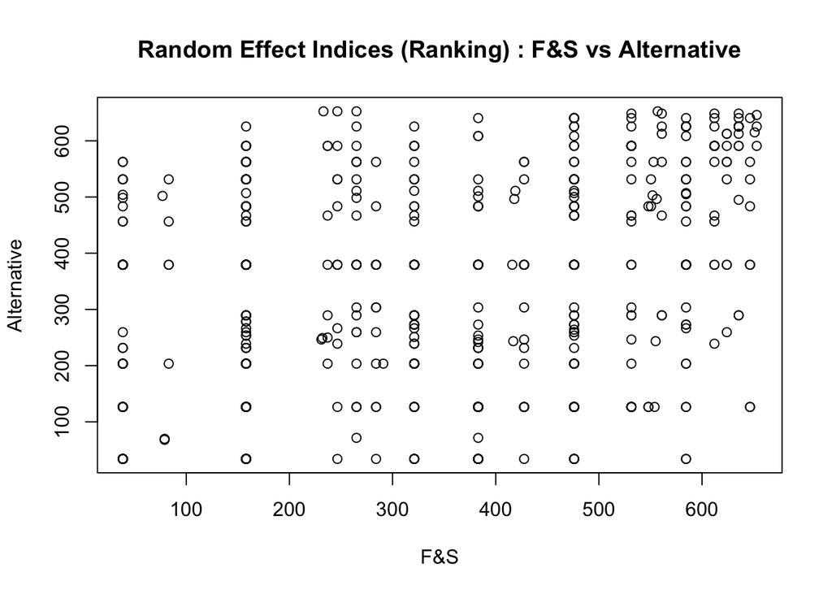

```r
plot(rank(ranef(rasch_lmer_FandS)$school[["(Intercept)"]]),
     rank(ranef(rasch_lmer_alt)$school[["(Intercept)"]]),
     xlab = "F&S", ylab = "Alternative",
     main = "Random Effect Indices (Ranking) : F&S vs Alternative")
```

## Model Comparison via Bootstrapping - Initialization

- What : Parallel nonparametric bootstrapping
- Why : To calculate and compare the expected length of the 95% CIs, means of random effect coefficients, and time spent for bootstrapping the two models
- How : Resampling bootstrap using parallel processing in R using “Parallel” package. I’m not using bootMer because we need to sample schools not school-answers (e.g. there’s a data format modification step needed to be executed after resampling but before bootMer execute/update the model.

```r
# Initialize parallel clusters
cl <- makeCluster(detectCores()-1)
invisible(clusterEvalQ(cl, c(library(lme4), library(dplyr), library(tidyr))))
clusterSetRNGStream(cl)
```

```r
ori_rasch_wide <- dataSecurity %>% dplyr::select(school, "38C", "38D", "38H", "38G", "38N", "40A", "38F")
alt_rasch_wide <- dataSecurity %>% dplyr::select(school, "38H", "38K", "38C", "38E", "40E", "39C", "38J")

ori_rasch <- ori_rasch_wide %>% tidyr::gather("item", "response", -school)
rasch_lmer <- glmer(response ~ 0 + item + (1 | school),
                             family = binomial, data = ori_rasch, nAGQ = 4)

resamplerWide = function(i, questionSet){
  whichrows <- sample(1L:nrow(questionSet), nrow(questionSet), replace = TRUE)
  bootspl <- questionSet[whichrows,] %>% tidyr::gather("item", "response", -school)
  refitted.mod <- update(rasch_lmer, data = bootspl)
  ranef(refitted.mod)
}

clusterExport(cl, c("ori_rasch_wide", "alt_rasch_wide", "rasch_lmer"))
```

```r
bootreps <- 500; cat("B = ", bootreps, "\n")
```

```
## B =  500
```

```r
start.time1 <- Sys.time()
bootstats_ori  <- parSapply(cl, 1:bootreps, FUN = resamplerWide, questionSet = ori_rasch_wide)
end.time1 <- Sys.time(); cat("Finn & Servoss : Processing Time =  ", end.time1 - start.time1, " min\n")
```

```
## Finn & Servoss : Processing Time =   49.38469  min
```

```r
start.time2 <- Sys.time()
bootstats_alt  <- parSapply(cl, 1:bootreps, FUN = resamplerWide, questionSet = alt_rasch_wide)
end.time2 <- Sys.time(); cat("Alternative    : Processing Time =  ", end.time2 - start.time2, " min\n")
```

```
## Alternative    : Processing Time =   45.02447  min
```

```r
stopCluster(cl)
```

- Note : Although in this session Finn & Servoss’ model takes longer to converge, in other re-runs mine takes longer.

## Model Comparison via Bootstrapping - Data Cleaning & Confidence Interval

- What : Data cleaning of the bootstrapped data and calculations of 95% bias-corrected & accelerated CI length
- Why : The bootsrapped data in replicate is in a form of list of multiple dataframes, need to combine them into one to then compute the confidence intervals of our random intercepts
- How : Simple dplyr group-by and summarise for confidence interval using bias-corrected and accelerated confidence intervals (DiCiccio & Efron, 1996). Implementation in R (bca) from Kropko & Harden (package = “coxed”; 2014)

```r
# "pasting" other bootstrap results into the data
dataCleaning <- function(bootstrappedData) {

  lmerBootContainer  <- data.frame(bootstrappedData[1])
  lmerBootContainer$index <- rownames(lmerBootContainer)
  lmerBootContainer$rep  <- 1
  colnames(lmerBootContainer)[1] <- "value"
  for (i in 2:bootreps){
    lmerBootAdd <- data.frame(bootstrappedData[i])
    lmerBootAdd$index <- rownames(lmerBootAdd)
    lmerBootAdd$rep <- i
    colnames(lmerBootAdd)[1] <- "value"
    lmerBootContainer <- rbind(lmerBootContainer, lmerBootAdd)
  }

  # statistics for the bootstrap coefficients
  lmerBoot  <- lmerBootContainer %>% dplyr::group_by(index) %>%
                  dplyr::summarise("mean" = mean(value, na.rm = TRUE),
                                   "LB_BCA_CI" = bca(value, conf.level = 0.95)[1],
                                   "UB_BCA_CI" = bca(value, conf.level = 0.95)[2],
                                   "CI_length" = UB_BCA_CI - LB_BCA_CI)
  return(list(lmerBootContainer, lmerBoot))
}
```

```r
ori_boot <- dataCleaning(bootstats_ori)
alt_boot <- dataCleaning(bootstats_alt)
```

## Expected CI Length Comparison

- What : Comparing the mean of the length of 95% confidence intervals

```r
mean(alt_boot[[2]]$CI_length)/ mean(ori_boot[[2]]$CI_length) - 1
```

```
## [1] 0.04561288
```

- Results : On average, security indices produced using Finn & Servoss’ model is 4.6% more precise than mine in a sense that on average their CIs are 4.6% tighter

## Density of Rasch Indices

- What : Comparing the density plots of Rasch indices (random intercepts) from the two models
- How : Density plots of Rasch indices two models

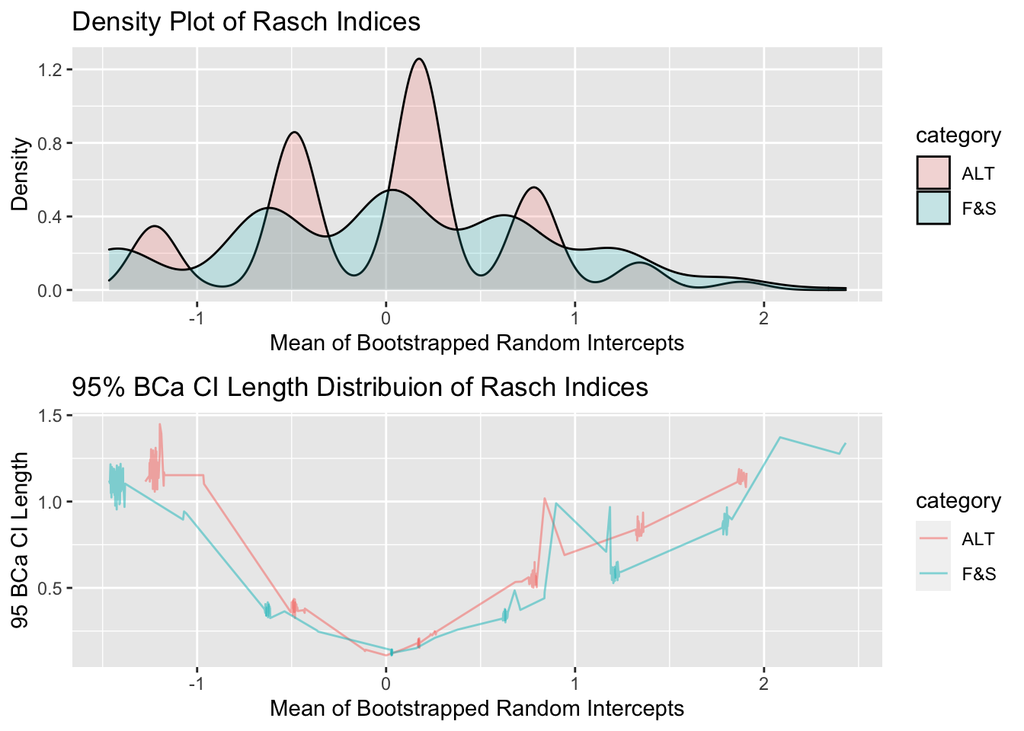

```r
ori_boot[[2]]$category <- "F&S"
alt_boot[[2]]$category <- "ALT"

boot_all <- rbind(ori_boot[[2]], alt_boot[[2]])

plot1 <- ggplot(boot_all, aes(x = mean, fill = category)) +
  geom_density(alpha = .2) +
  ggtitle("Density Plot of Rasch Indices") +
  labs(x = "Mean of Bootstrapped Random Intercepts", y = "Density")

plot2 <- ggplot(boot_all, aes(x = mean, y = CI_length, color = category)) +
  geom_line(alpha = .5) +
  ggtitle("95% BCa CI Length Distribuion of Rasch Indices") +
  labs(x = "Mean of Bootstrapped Random Intercepts", y = "95 BCa CI Length")

grid.arrange(plot1, plot2)
```

- Results : It seems that Finn & Servoss’ model enables more statistically significant comparisons between schools security indices because my model’s random intercepts are more concentrated in few points rather than scattered out while also at the same time having larger expected CI length. Moreover, the 95% BCa CI of my security indices are wider almost at all points compared to Finn & Servoss’. In general, both models are more precise in the midpoints and less as indices approach the edges

## Future Analysis

Previously, we chose the questions based on literature analysis (e.g. what are the security questions that seemingly the least qualitatively overlapping with each other). Based on our prior analyses, it seems that constructing questions that forms a stable hierarchy (e.g. pick n questions that ranges from most common among schools to the least common, as evident in the fixed effect coefficients of Finn & Servoss’ model). The previous inference seems align with the intuition in constructing an exam; form a set of questions consists from easy to hard challenges. The aforementioned strategy can be achieved by ordering all the security questions ascendingly w.r.t how many schools answer yes and split them into n groups and then select kth question in each group.